# Job Analysis for Data Science

2024-06-04

## Content

Introduction

1. Scatter Plot on Salary v Experience Level
2. Salary Brackets for Data Scientists
3. Salary of the 5 Most Common Job Index
4. Mean and Median Salaries for Top 5 Job Titles
5. Standard Deviation of Salaries for Top 5 Job Titles
6. Conlcusion

## Introduction

In this presentation, I will analyzing data science salaries based on various factors which includes Job title, Experience level, and Work model. I will also perform some calculation that will give back a pattern as I also want to get a career in Data Science. I will be making a metric of my own so that the data can be quantified and there is a pattern to what we will be seeing in this data set.

## Salary vs Experience Level

This is a Scatter Plot that shows us a pattern between how the Salary is based on Experience Level

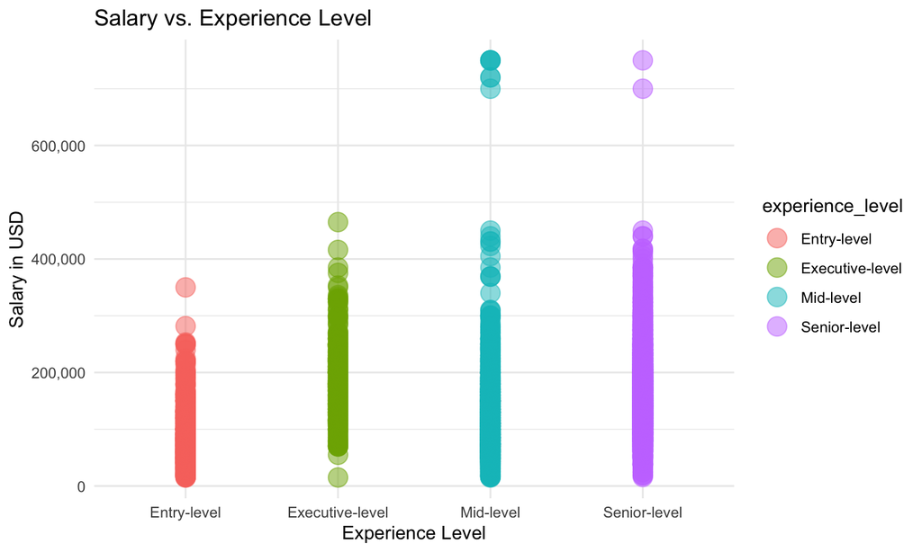

## Salary Brackets for Data Scientists

Here I have made a Bar plot on the Brackets for how much Data Scientists make.

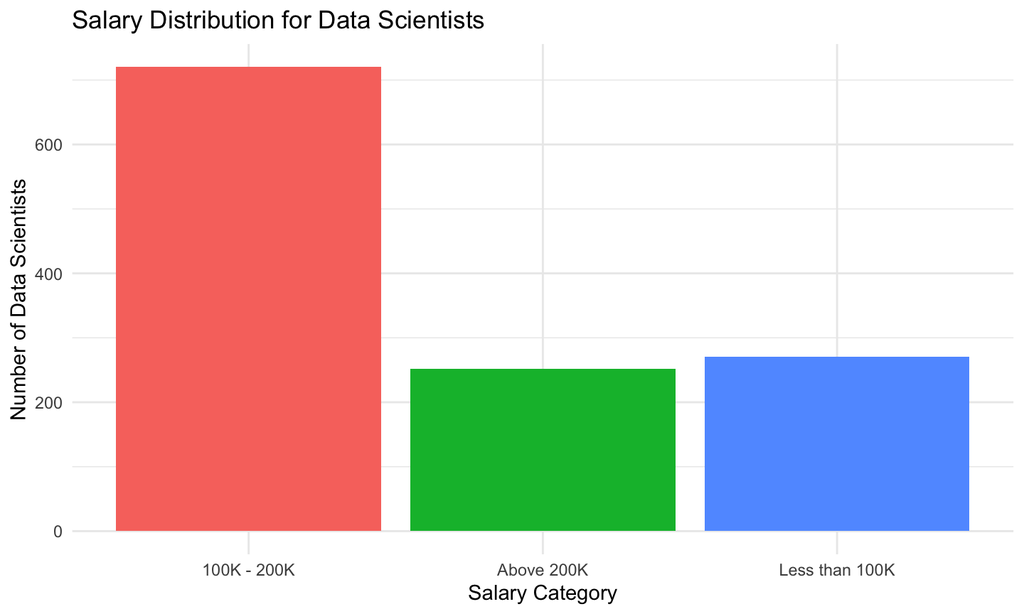

## Salaries of the 5 most common Job Titles and the Number of People that choose it

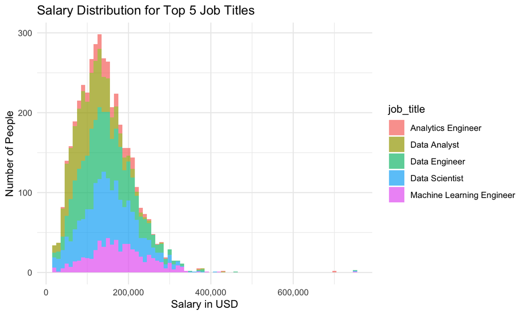

## Code

```r
# Get the top 5 most common job titles
top_job_titles <- data %>%
  count(job_title) %>%
  top_n(5, n) %>%
  pull(job_title)

# Filter the data to include only the top 5 job titles
filtered_data <- data %>%
  filter(job_title %in% top_job_titles)

# Histogram of salary_in_usd by job_title for the top 5 job titles
ggplot(filtered_data, aes(x = salary_in_usd, fill = job_title)) +
  geom_histogram(binwidth = 10000, alpha = 0.7) +
  theme_minimal() +
  labs(title = "Salary Distribution for Top 5 Job Titles",
       x = "Salary in USD",
       y = "Number of People") +
  scale_x_continuous(labels = scales::comma)
```

## Mean and Median Calculation

Let’s calculate the mean and median salaries for the top 5 most common job titles.

### Mean Calculation

The mean salary (\(\mu\)) is calculated as follows:

\[ \mu = \frac{1}{n} \sum_{i=1}^n x_i \]

### Median Calculation

The median salary is the middle value when the salaries are sorted in ascending order.

## Calculations

```
## # A tibble: 5 × 3
##   job_title                 mean_salary median_salary
##   <chr>                           <dbl>         <dbl>
## 1 Analytics Engineer            156337.        145650
## 2 Data Analyst                  106932.        102000
## 3 Data Engineer                 144540.        136000
## 4 Data Scientist                149037.        144500
## 5 Machine Learning Engineer     177226.        170730
```

## Standard Deviation Calculation

Let’s calculate the standard deviation of salaries for the top 5 most common job titles.

### Standard Deviation Calculation

The standard deviation (\(\sigma\)) is calculated as follows:

\[ \sigma = \sqrt{\frac{1}{n} \sum_{i=1}^n (x_i - \mu)^2} \]

## Calculation

```
## # A tibble: 5 × 2
##   job_title                 sd_salary
##   <chr>                         <dbl>
## 1 Analytics Engineer           73117.
## 2 Data Analyst                 47604.
## 3 Data Engineer                64621.
## 4 Data Scientist               65684.
## 5 Machine Learning Engineer    72770.
```

## Conclusion

In this analysis, we examined the salaries of data science professionals across different job titles. Our key findings include:

## Insight

High Demand for Machine Learning Engineers:

ML Engineers have the highest mean and median salaries, indicating a strong demand and specialized skill set required for this role.

Data Scientists:

Data Scientists also command high salaries, reflecting their crucial role in deriving insights from data and driving decision-making.